# sample

谢润兰

2026-05-08

# 根系数据

```r
library(readxl)
library(dplyr)
library(ggplot2)
library(corrplot)
library(FactoMineR)
library(factoextra)
root <- read_excel("./Data/root.xlsx")
root$species <- as.factor(root$species)
```

### 比较氮吸收速率的种间差异

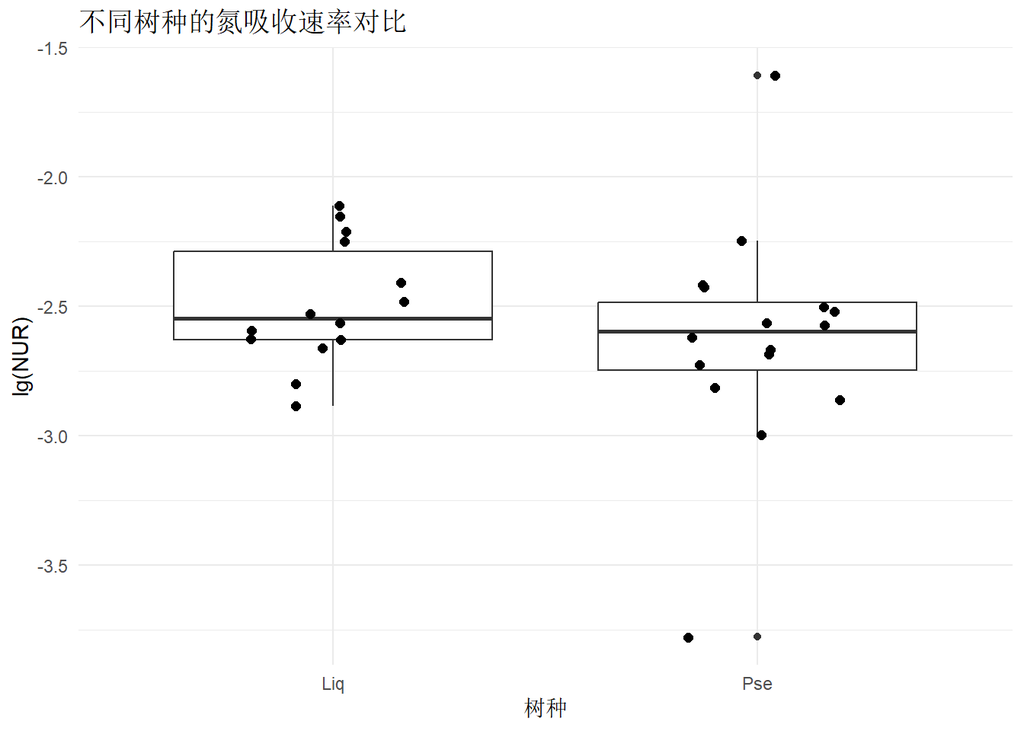

```
            Df Sum Sq Mean Sq F value Pr(>F)
species      1  0.131  0.1309   1.016  0.322
Residuals   28  3.608  0.1289
```

```r
#单因素方差分析
aov_model <- aov(NUR_log ~ species, data = root)
summary(aov_model)
#箱线图展示分布
ggplot(root, aes(x = species, y = NUR_log)) +
  geom_boxplot() +
  geom_jitter(width = 0.2, size = 2) +
  labs(title = "不同树种的氮吸收速率对比", y = "lg(NUR)", x = "树种") +
  theme_minimal()
```

两个树种之间的氮吸收速率无显著差异（p>0.05），分布重叠多。

### 比较根系形态指标的种间差异

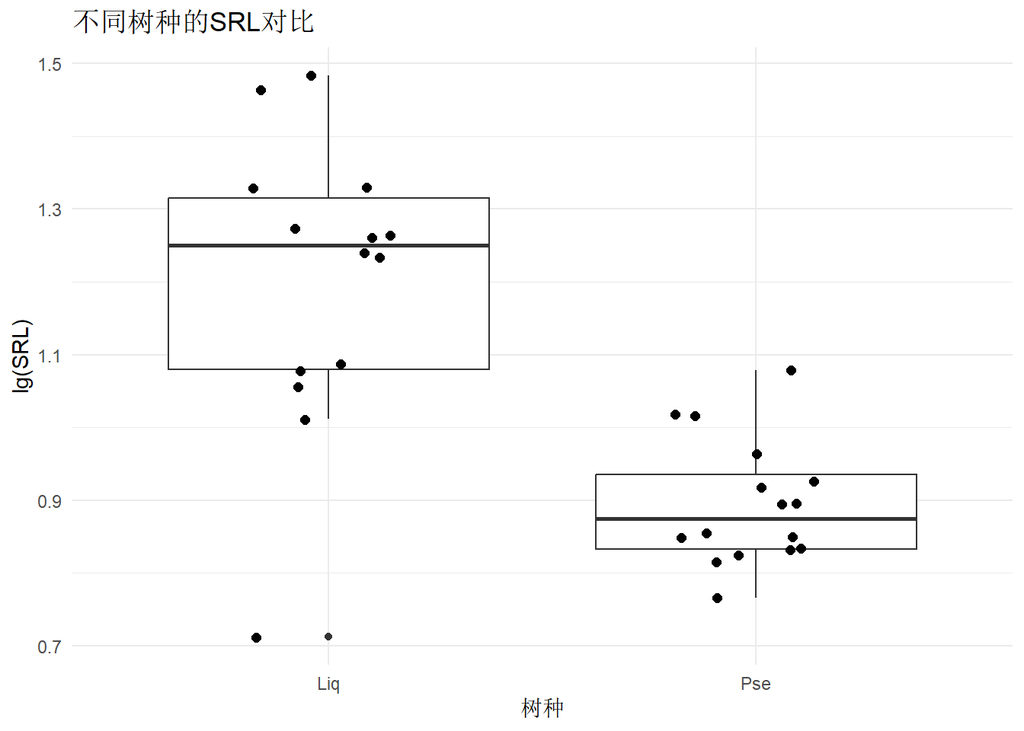

```
            Df Sum Sq Mean Sq F value   Pr(>F)
species      1 0.6976  0.6976   30.86 6.09e-06 ***
Residuals   28 0.6329  0.0226
---
Signif. codes:  0 '***' 0.001 '**' 0.01 '*' 0.05 '.' 0.1 ' ' 1
```

```r
aov_srl <- aov(SRL_log ~ species, data = root)
summary(aov_srl)
#其他指标类似
#aov_avgdiam <- aov(AvgDiam_log ~ species, data = root)
#aov_rtd <- aov(RTD_log ~ species, data = root)
#aov_sra <- aov(SRA_log ~ species, data = root)
ggplot(root, aes(x = species, y = SRL_log)) +
  geom_boxplot() +
  geom_jitter(width = 0.2, size = 2) +
  labs(title = "不同树种的SRL对比", y = "lg(SRL)", x = "树种") +
  theme_minimal()
```

两个树种在比根长（SRL）上存在显著差异（p<0.05）。

### 散点图矩阵

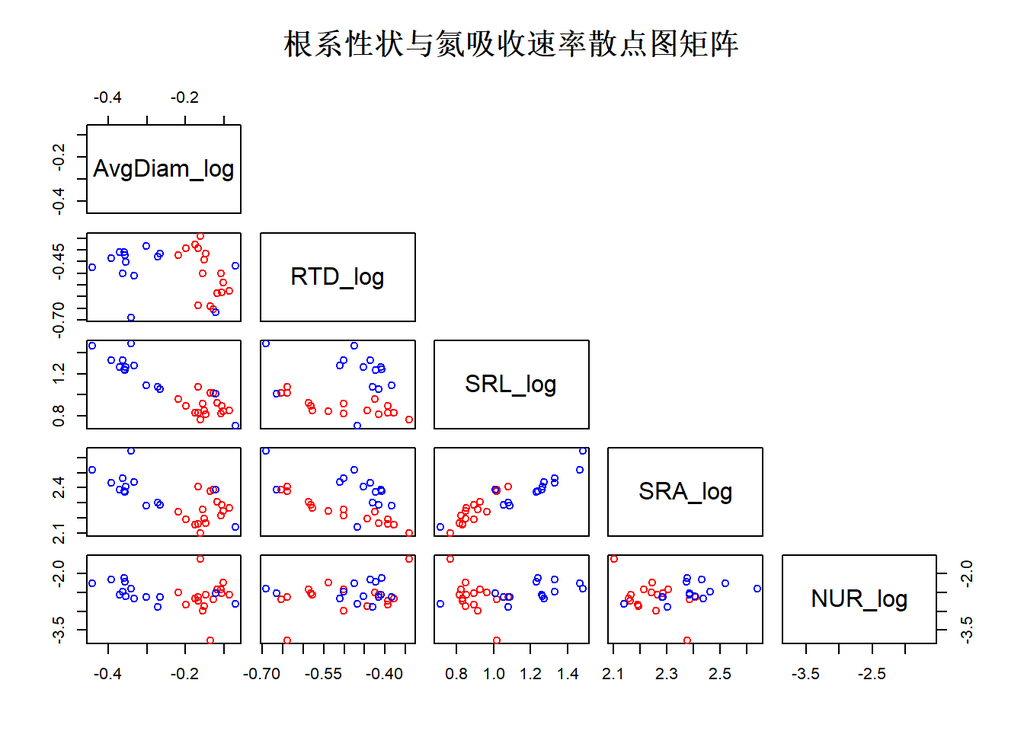

```r
pairs(root[, c("AvgDiam_log", "RTD_log", "SRL_log", "SRA_log", "NUR_log")],
      col = c("blue", "red")[as.numeric(root$species)],
      upper.panel = NULL,
      main = "根系性状与氮吸收速率散点图矩阵")
```

### Pearson相关性矩阵

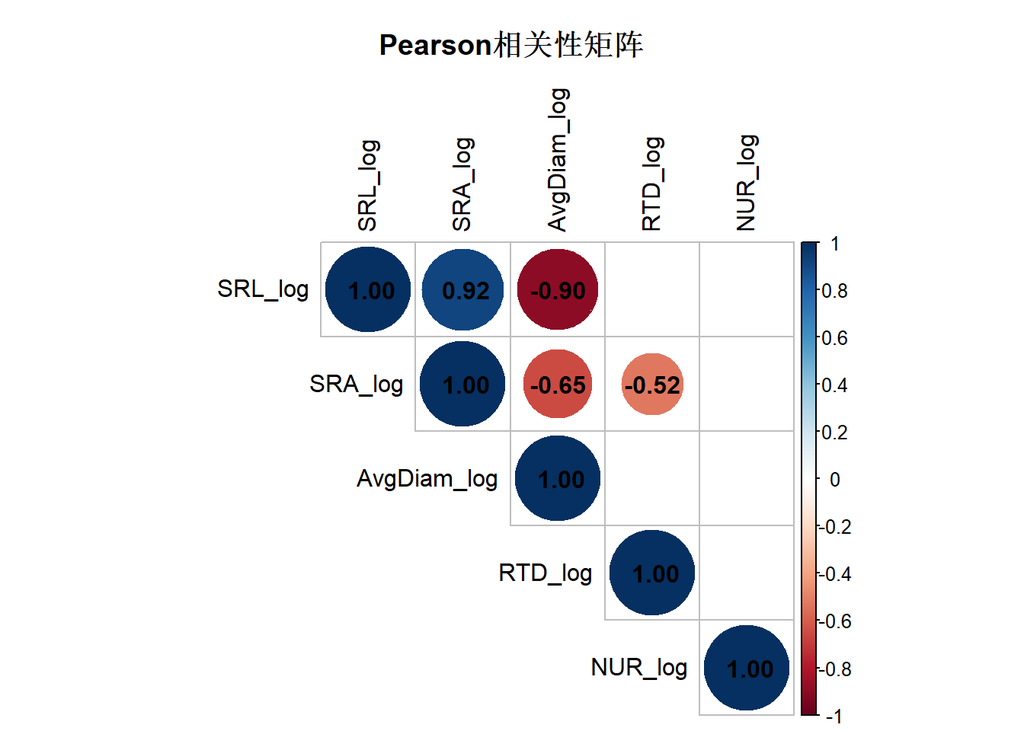

```r
cor_var <- select(root, AvgDiam_log, RTD_log, SRL_log, SRA_log, NUR_log)
cor_res <- cor(cor_var)
cor_p <- cor.mtest(cor_var, conf.level = 0.95)$p
corrplot(cor_res, type = "upper", order = "hclust",
         p.mat = cor_p, sig.level = 0.05, insig = "blank",
         addCoef.col = "black", tl.col = "black",
         title = "Pearson相关性矩阵",
         mar = c(0,0,3,0))
```

比根长SRL与比根面积SRA呈显著正相关，平均直径AvgDiam与SRL、SRA呈显著负相关；各单一根系性状与氮吸收速率NUR无显著的线性关系。

### 线性回归

```r
#全模型
model_full <- lm(NUR_log ~ AvgDiam_log+RTD_log+SRL_log+SRA_log+species,
                 data = root)
summary(model_full)
```

```
Call:
lm(formula = NUR_log ~ AvgDiam_log + RTD_log + SRL_log + SRA_log +
    species, data = root)

Residuals:
     Min       1Q   Median       3Q      Max
-0.98238 -0.18044  0.02036  0.18774  0.85575

Coefficients:
              Estimate Std. Error t value Pr(>|t|)
(Intercept) -2.611e+03  4.909e+03  -0.532    0.600
AvgDiam_log -1.711e+03  3.289e+03  -0.520    0.608
RTD_log      1.649e+01  1.986e+01   0.830    0.415
SRL_log     -1.726e+03  3.284e+03  -0.526    0.604
SRA_log      1.742e+03  3.279e+03   0.531    0.600
speciesPse   8.825e-03  2.132e-01   0.041    0.967

Residual standard error: 0.3619 on 24 degrees of freedom
Multiple R-squared:  0.1591,    Adjusted R-squared:  -0.01603
F-statistic: 0.9085 on 5 and 24 DF,  p-value: 0.492
```

```r
#逐步回归选变量
model_step <- step(model_full, direction = "both", trace = FALSE)
summary(model_step)
```

```
Call:
lm(formula = NUR_log ~ RTD_log, data = root)

Residuals:
     Min       1Q   Median       3Q      Max
-1.06538 -0.20261  0.01783  0.23300  0.80929

Coefficients:
            Estimate Std. Error t value Pr(>|t|)
(Intercept)  -2.0793     0.3318  -6.267 8.95e-07 ***
RTD_log       0.9883     0.6654   1.485    0.149
---
Signif. codes:  0 '***' 0.001 '**' 0.01 '*' 0.05 '.' 0.1 ' ' 1

Residual standard error: 0.3518 on 28 degrees of freedom
Multiple R-squared:  0.07303,   Adjusted R-squared:  0.03993
F-statistic: 2.206 on 1 and 28 DF,  p-value: 0.1486
```

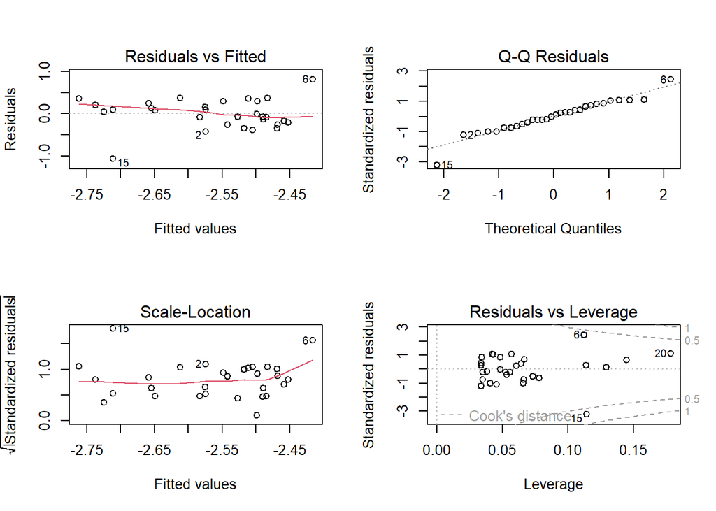

```r
par(mfrow = c(2,2))
plot(model_step)
```

逐步回归法筛选出**根组织密度（RTD_log）**，但回归模型拟合差

### 主成分分析（PCA）

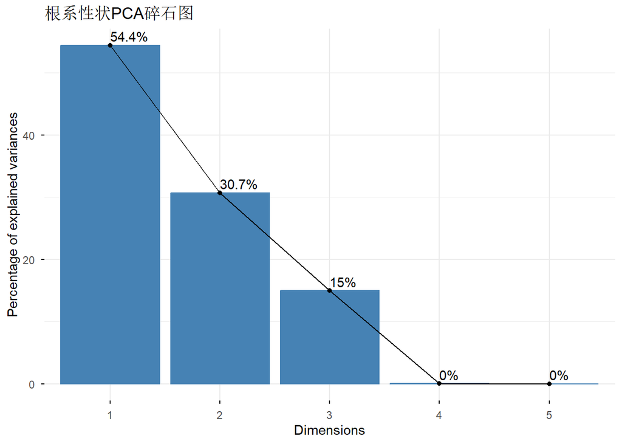

```r
pca_data <- root[, c("AvgDiam_log","RTD_log","SRL_log","SRA_log","NUR_log")]
pca_result <- PCA(pca_data, scale.unit = TRUE, graph = FALSE)

fviz_eig(pca_result, addlabels = TRUE, title = "根系性状PCA碎石图")
```

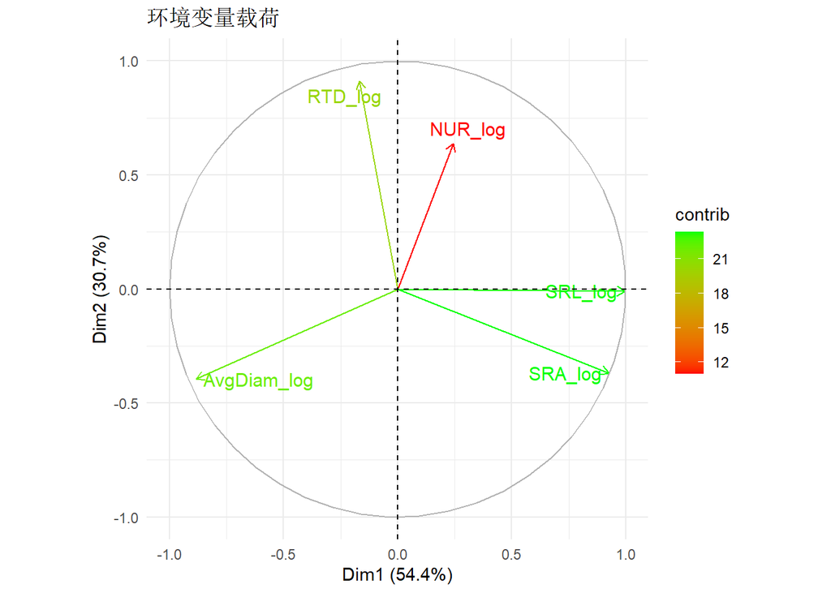

```r
fviz_pca_var(
  pca_result,
  col.var = "contrib",
  gradient.cols = c("red", "green"),
  repel = TRUE,
  title = "环境变量载荷")+
  theme_minimal()
```

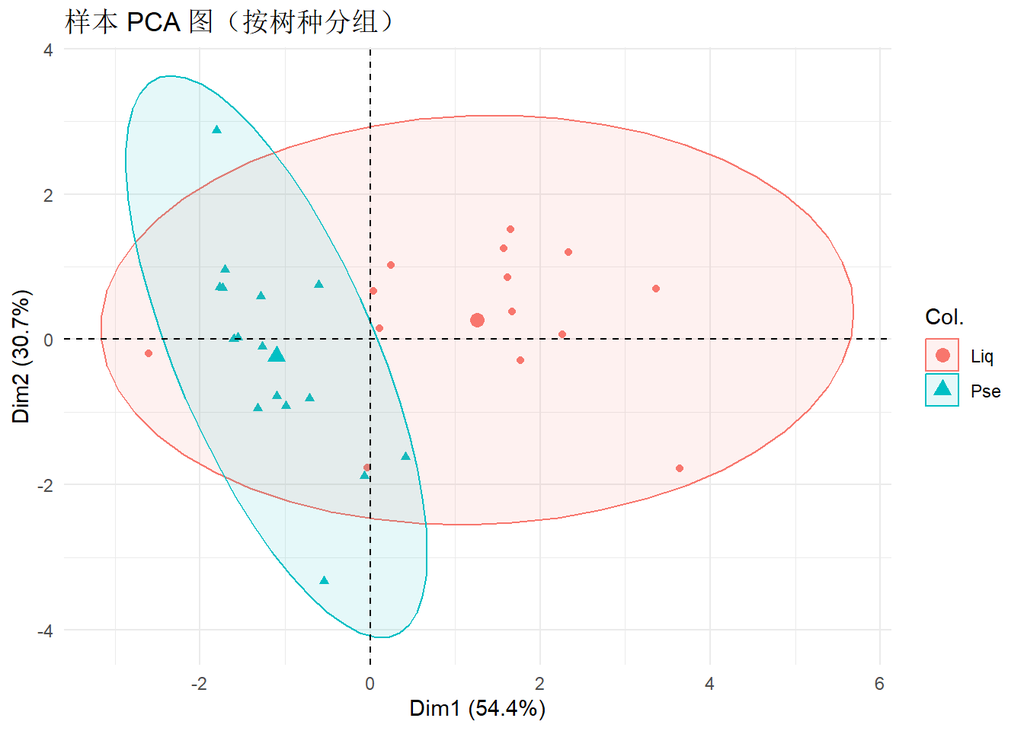

```r
fviz_pca_ind(
  pca_result,
  label = "none",
  col.ind  = root$species,
  addEllipses = TRUE,
  title = "样本 PCA 图（按树种分组）")  +
  theme_minimal()
```

前两个主成分共同解释85.1%的变异。 PC1与SRL、SRA呈强正相关，与AvgDiam呈强负相关，PC2与RTD呈强正相关，NUR的贡献度较低。 两个树种（Liq与Pse）的95%置信椭圆存在较大重叠，根系性状整体区分不明显。

# maxent模型预测适生区

```r
library(biomod2)
library(terra)
species_points <- read_excel("./Data/species.xlsx")
env_stack <- rast(c("./Data/bio2.tif","./Data/bio3.tif","./Data/bio14.tif","./Data/bio15.tif","./Data/elev.tif"))
names(env_stack) <- c("bio2", "bio3", "bio14", "bio15", "elev")
```

### 生成背景点

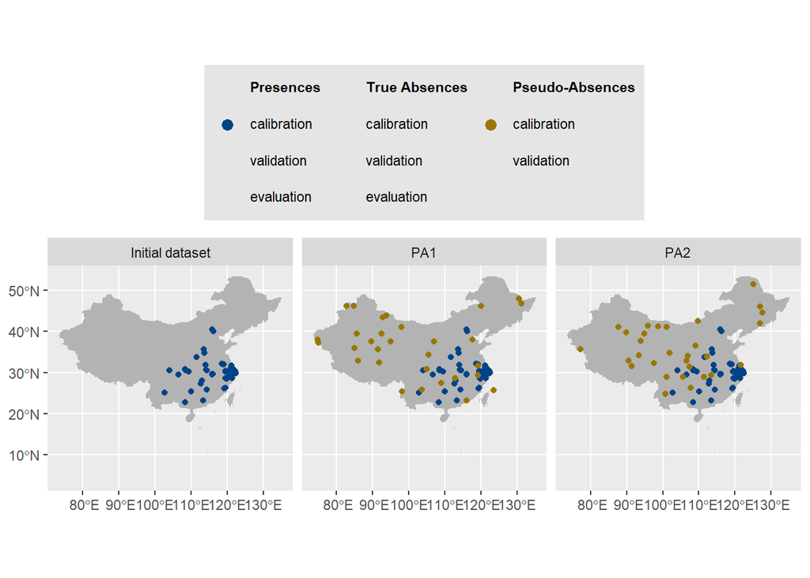

```r
PT_data <- BIOMOD_FormatingData(
  resp.name = "SDM_sample",
  resp.var = rep(1, nrow(species_points)),
  resp.xy = species_points,
  expl.var = env_stack,
  PA.nb.rep = 2,
  PA.nb.absences = 30,
  PA.strategy = 'random')
species_plot <- plot(PT_data)
```

生成2组伪不存在点，每组30个

### 建模和评估（MAXNET）

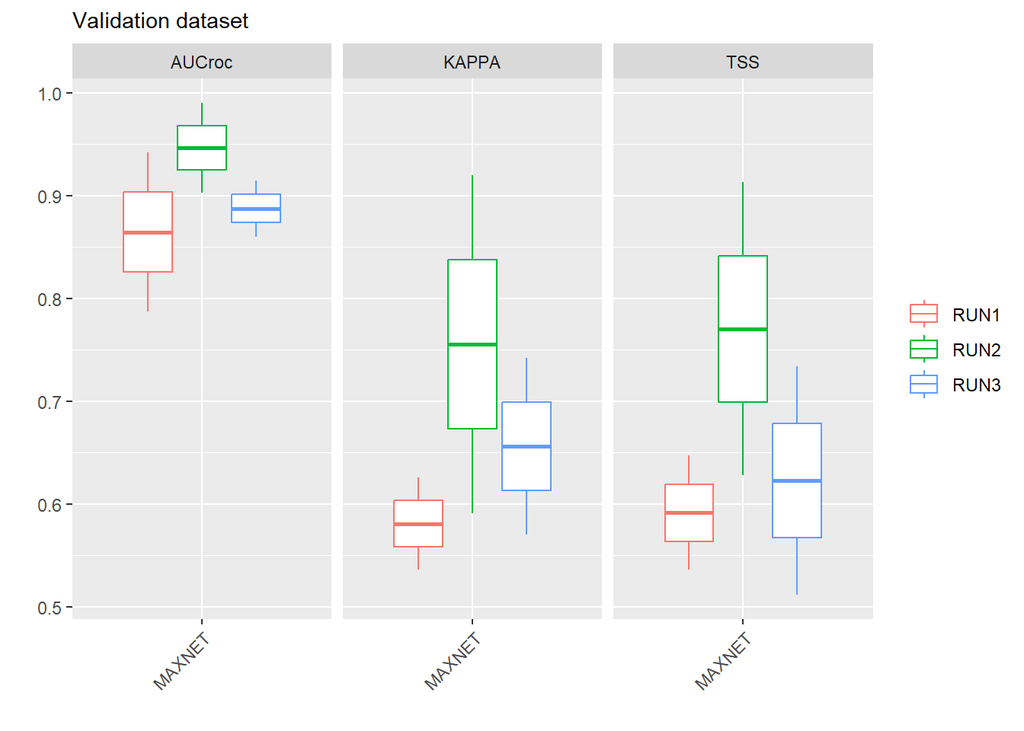

```r
PT_Model <- BIOMOD_Modeling(
  bm.format = PT_data,
  models = "MAXNET",
  CV.strategy = 'random',
  CV.nb.rep = 3,
  CV.perc = 0.7,
  OPT.strategy = 'bigboss',
  var.import = 3)
eval_plot <- bm_PlotEvalBoxplot(
  bm.out = PT_Model,
  dataset = 'validation',
  group.by = c('algo','run'))
```

### 变量重要性（柱状图）

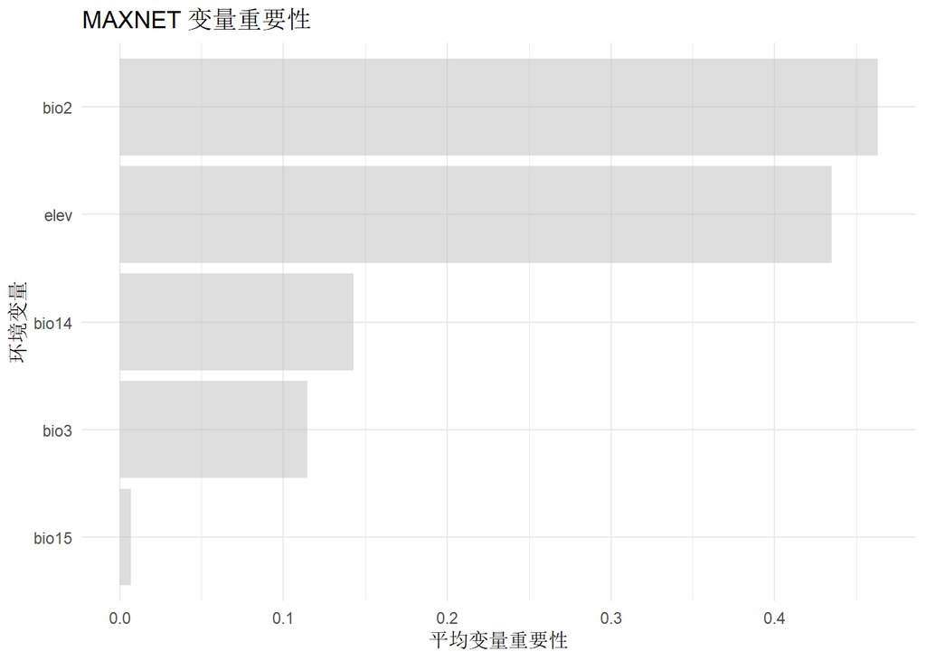

```r
var_imp <- get_variables_importance(PT_Model)
var_imp_grouped <- group_by(var_imp, expl.var)
var_imp_mean <- summarise(var_imp_grouped, mean_imp = mean(var.imp, na.rm = TRUE))
ggplot(var_imp_mean, aes(x = reorder(expl.var, mean_imp), y = mean_imp)) +
  geom_col(fill = "gray",alpha=0.5) +
  coord_flip() +
  labs(x = "环境变量", y = "平均变量重要性",
       title = "MAXNET 变量重要性") +
  theme_minimal()
```

### 响应曲线

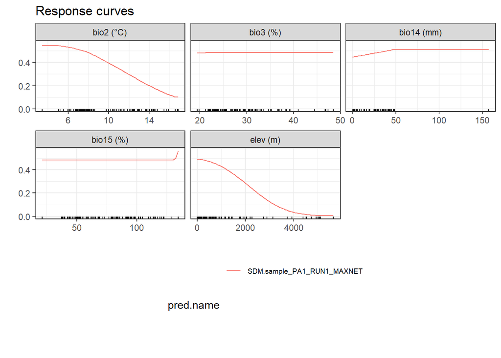

```r
resp <-bm_PlotResponseCurves(
  bm.out = PT_Model,
  models.chosen = 'SDM.sample_PA1_RUN1_MAXNET',
  fixed.var = 'median',
  do.plot = FALSE,
  main="Response curves")
resp$plot +
  theme_bw()+
  theme(legend.position = "bottom",
        legend.text = element_text(size = 7))+
  facet_wrap(
    ~expl.name,
    scales = "free_x",
    labeller = labeller(
      expl.name = function(x) {
        dplyr::case_when(
          x == "bio2"  ~ "bio2 (°C)",
          x == "bio3"  ~ "bio3 (%)",
          x == "bio14" ~ "bio14 (mm)",
          x == "bio15" ~ "bio15 (%)",
          x == "elev" ~ "elev (m)",
          TRUE ~ x        )      }  ) )+
  guides(colour = guide_legend(nrow = 4))
```

平均昼夜温差bio2在7.5℃以上，适生概率降至0.5以下。

### 适生区空间分布

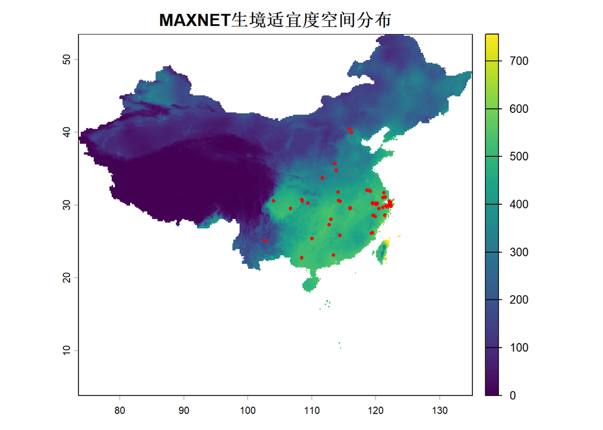

```r
myProj <- BIOMOD_Projection(
  bm.mod = PT_Model,
  proj.name = "Current",
  new.env = env_stack,
  models.chosen = "SDM.sample_PA1_RUN1_MAXNET",
  build.clamping.mask = FALSE
)
pred <- get_predictions(myProj)
plot(pred, main = "MAXNET生境适宜度空间分布")
points(species_points, pch = 10, cex = 0.5, col = "red")
```

# 野外样方

### 物种累积曲线

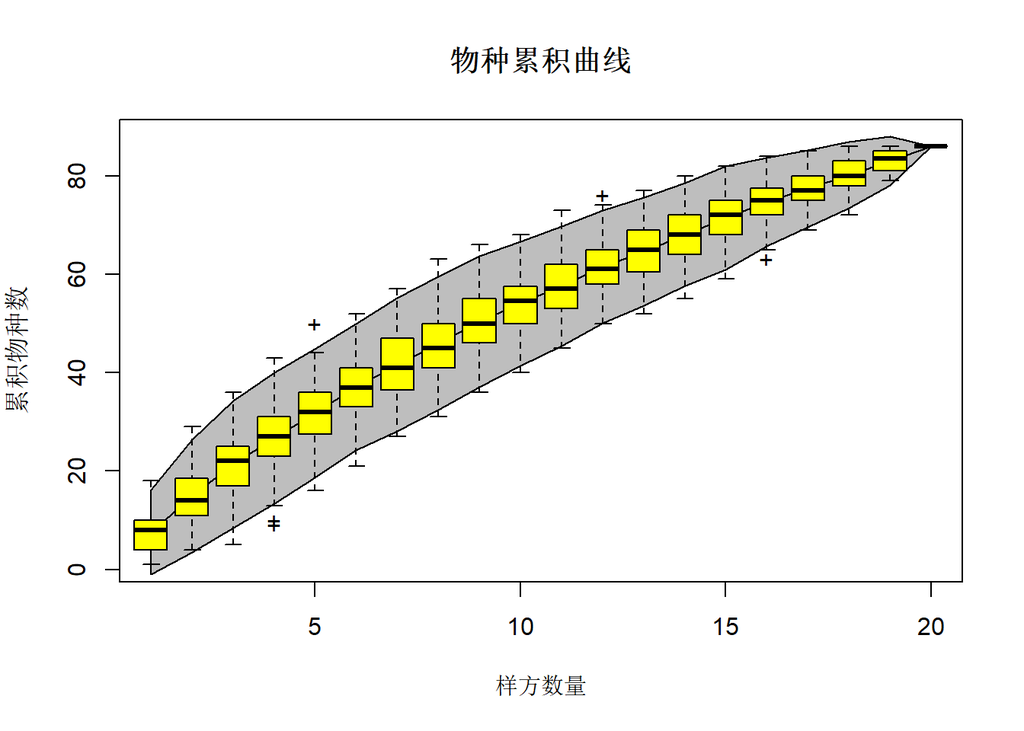

```r
library(vegan)
SAC <- read_excel("20sites.xlsx")
SAC=SAC[,-1]
sp <- specaccum(SAC, method="random")
plot(sp,ci.type="poly",ci.col="gray",ylab="累积物种数",xlab="样方数量",main="物种累积曲线")
boxplot(sp, col="yellow", add=TRUE, pch="+")
```

数据包含20个样方，累积物种数持续增加，未观察到平缓状态，样方数量有待增加。

### 丰度等级曲线

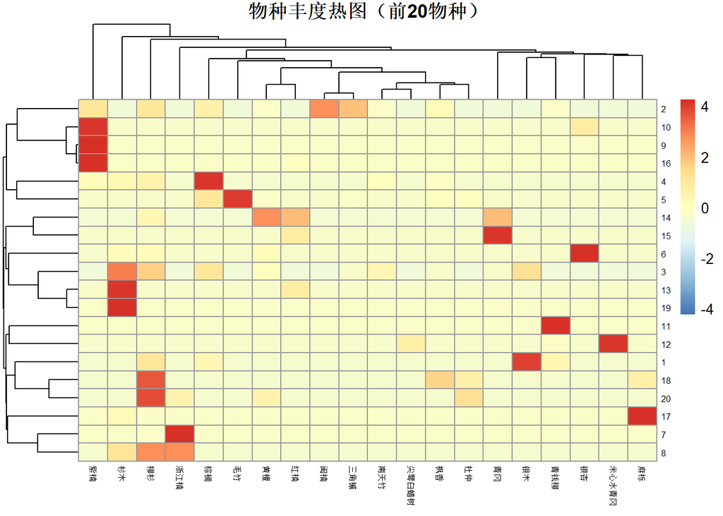

```r
library(pheatmap)
otu <- read_excel("20sites.xlsx")
otu <- otu[, -1]
otu_top <- otu[, order(colSums(otu), decreasing = TRUE)[1:20]]
pheatmap(otu_top,
         scale = "row",
         fontsize_row = 6,
         fontsize_col = 5,
         main = "物种丰度热图（前20物种）")
```

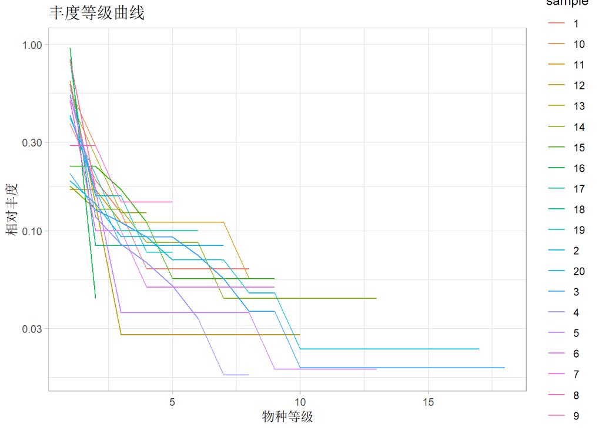

```r
#丰度等级曲线
otu_relative <- otu / rowSums(otu)
rank_list <- lapply(1:20, function(i) {
  abund_vec <- as.numeric(otu_relative[i, ])
  abund <- abund_vec[abund_vec > 0]
  sorted_abund <- sort(abund, decreasing = TRUE)
  df <- data.frame(
    rank = 1:length(sorted_abund),
    abundance = sorted_abund,
    sample = rownames(otu_relative)[i]
  )
})
rank_dat <- do.call(rbind, rank_list)
ggplot(rank_dat, aes(x = rank, y = abundance, group = sample, color = sample)) +
  geom_line() +
  scale_y_log10() +
  labs(x = "物种等级", y = "相对丰度", title = "丰度等级曲线") +
  theme_light()
```

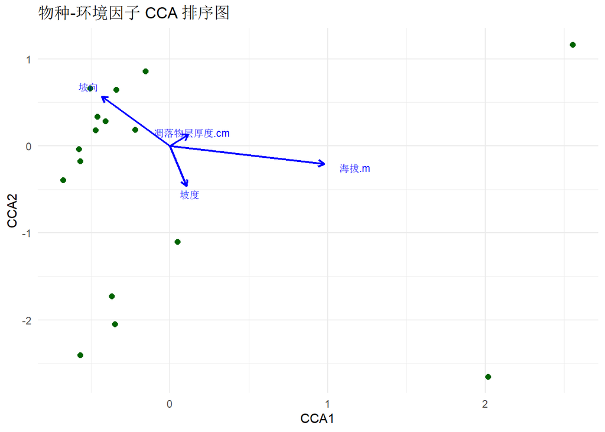

```r
#CCA
env <- read.csv("环境因子.csv", header = TRUE)
rownames(env) <- 1:20
env_complete <- na.omit(env[, c("海拔.m", "凋落物层厚度.cm", "坡度", "坡向")])
otu_complete <- otu[which(rownames(otu) %in% rownames(env_complete)), ]
result <- cca(otu_complete, env_complete)
site_scores <- scores(result, display = "sites")
env_vectors <- scores(result, display = "bp")
cca_sites <- data.frame(site_scores, sample = rownames(site_scores))
cca_env <- data.frame(env_vectors, label = rownames(env_vectors))
ggplot(cca_sites, aes(x = CCA1, y = CCA2)) +
  geom_point(size = 2, color = "darkgreen") +
  geom_segment(data = cca_env,
               aes(x = 0, y = 0, xend = CCA1, yend = CCA2),
               arrow = arrow(length = unit(0.2, "cm")),
               color = "blue", linewidth = 0.8) +
  geom_text(data = cca_env,
            aes(x = CCA1 * 1.2, y = CCA2 * 1.2, label = label),
            color = "blue", size = 3) +
  labs(title = "物种-环境因子 CCA 排序图") +
  theme_minimal()
```